# Loan_Modelling

```python
import numpy as np
import pandas as pd
import seaborn as sns
import matplotlib.pyplot as plt
%matplotlib inline
```

```python
df=pd.read_csv('Bank_Personal_Loan_Modelling (1).csv')
```

```python
df.head()
```

|  | ID | Age | Experience | Income | ZIP Code | Family | CCAvg | Education | Mortgage | Personal Loan | Securities Account | CD Account | Online | CreditCard |
| --- | --- | --- | --- | --- | --- | --- | --- | --- | --- | --- | --- | --- | --- | --- |
| 0 | 1 | 25 | 1 | 49 | 91107 | 4 | 1.6 | 1 | 0 | 0 | 1 | 0 | 0 | 0 |
| 1 | 2 | 45 | 19 | 34 | 90089 | 3 | 1.5 | 1 | 0 | 0 | 1 | 0 | 0 | 0 |
| 2 | 3 | 39 | 15 | 11 | 94720 | 1 | 1.0 | 1 | 0 | 0 | 0 | 0 | 0 | 0 |
| 3 | 4 | 35 | 9 | 100 | 94112 | 1 | 2.7 | 2 | 0 | 0 | 0 | 0 | 0 | 0 |
| 4 | 5 | 35 | 8 | 45 | 91330 | 4 | 1.0 | 2 | 0 | 0 | 0 | 0 | 0 | 1 |

```python
df.shape
```

```
(5000, 14)
```

```python
df.isnull().sum()
```

```
ID                    0
Age                   0
Experience            0
Income                0
ZIP Code              0
Family                0
CCAvg                 0
Education             0
Mortgage              0
Personal Loan         0
Securities Account    0
CD Account            0
Online                0
CreditCard            0
dtype: int64
```

2. Study the data distribution in each attribute, share your findings(15 marks)

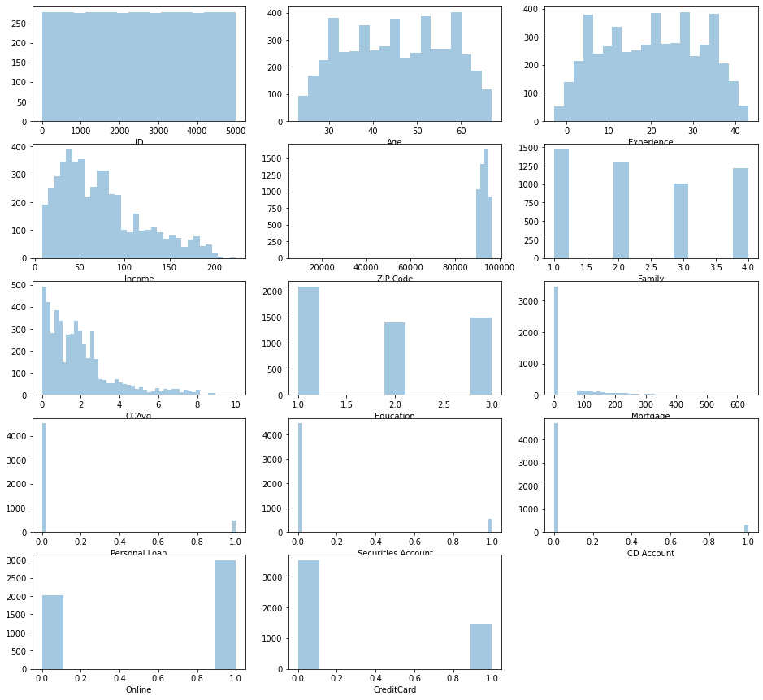

```python
fig=plt.figure(figsize=(16,15))
columns=df.columns

for x, i in zip(columns, range(len(columns))):
    ax=fig.add_subplot(5,3,i+1)
    sns.distplot(df[x], kde=False,)
#     ax.set_title(x)
```

```python
df.describe()
```

|  | ID | Age | Experience | Income | ZIP Code | Family | CCAvg | Education | Mortgage | Personal Loan | Securities Account | CD Account | Online | CreditCard |
| --- | --- | --- | --- | --- | --- | --- | --- | --- | --- | --- | --- | --- | --- | --- |
| count | 5000.000000 | 5000.000000 | 5000.000000 | 5000.000000 | 5000.000000 | 5000.000000 | 5000.000000 | 5000.000000 | 5000.000000 | 5000.000000 | 5000.000000 | 5000.00000 | 5000.000000 | 5000.000000 |
| mean | 2500.500000 | 45.338400 | 20.104600 | 73.774200 | 93152.503000 | 2.396400 | 1.937938 | 1.881000 | 56.498800 | 0.096000 | 0.104400 | 0.06040 | 0.596800 | 0.294000 |
| std | 1443.520003 | 11.463166 | 11.467954 | 46.033729 | 2121.852197 | 1.147663 | 1.747659 | 0.839869 | 101.713802 | 0.294621 | 0.305809 | 0.23825 | 0.490589 | 0.455637 |
| min | 1.000000 | 23.000000 | -3.000000 | 8.000000 | 9307.000000 | 1.000000 | 0.000000 | 1.000000 | 0.000000 | 0.000000 | 0.000000 | 0.00000 | 0.000000 | 0.000000 |
| 25% | 1250.750000 | 35.000000 | 10.000000 | 39.000000 | 91911.000000 | 1.000000 | 0.700000 | 1.000000 | 0.000000 | 0.000000 | 0.000000 | 0.00000 | 0.000000 | 0.000000 |
| 50% | 2500.500000 | 45.000000 | 20.000000 | 64.000000 | 93437.000000 | 2.000000 | 1.500000 | 2.000000 | 0.000000 | 0.000000 | 0.000000 | 0.00000 | 1.000000 | 0.000000 |
| 75% | 3750.250000 | 55.000000 | 30.000000 | 98.000000 | 94608.000000 | 3.000000 | 2.500000 | 3.000000 | 101.000000 | 0.000000 | 0.000000 | 0.00000 | 1.000000 | 1.000000 |
| max | 5000.000000 | 67.000000 | 43.000000 | 224.000000 | 96651.000000 | 4.000000 | 10.000000 | 3.000000 | 635.000000 | 1.000000 | 1.000000 | 1.00000 | 1.000000 | 1.000000 |

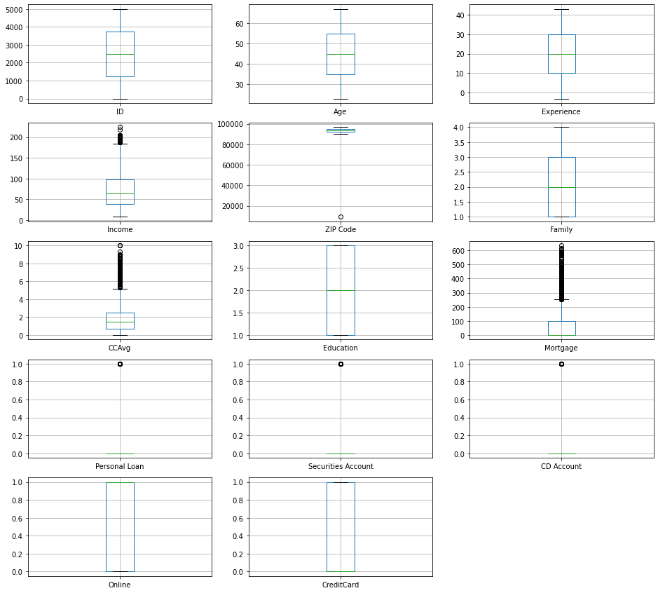

```python
fig=plt.figure(figsize=(16,15))
columns=df.columns

for x, i in zip(columns, range(len(columns))):
    ax=fig.add_subplot(5,3,i+1)
    df.boxplot(x)
```

##### 10. Personal Loan - This columns indicates that how much percentage of people accepted the offer last time and as we can see from the graph, only minuscle proportion of people accepted the offer.

##### 11. Securities Amount - Only small portion of people have Securities Account in Bank and the proportion of people who have securities account in bank is in line with people who accepted the offer last year, not necessarily that same people accepted the offer.

##### 12. CD Account - Lesser number of people surveyed last year had CD account in bank as compared to the securities account in BanK.

##### 13. Online - From the distribution graph it can be seen that around 60 percentage of the people use banking facilities.

3. Get the target column distribution. Your comments (5 marks)

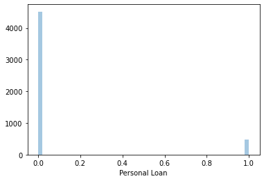

```python
 sns.distplot(df['Personal Loan'], kde=False,)
```

```python
loan_given=len(df[df['Personal Loan']==1])
loan_not_given=len(df[df['Personal Loan']==0])

print(f"Percentage of people for which loans were given: {(loan_given)/len(df)} ")
print(f"Percentage of people for which loans were not given:{(loan_not_given)/len(df)} ")
```

```
Percentage of people for which loans were given: 0.096
Percentage of people for which loans were not given:0.904
```

Comment -

From the above we can see that only 9.6% of the people last year accepted the offer.

Offer acceptance is highly imbalanced.

4. Split the data into training and test set in the ratio of 70:30 respectively (5 marks)

```python
X = df.drop(['Personal Loan', 'ID'], axis=1)
y=df['Personal Loan']
```

```python
from sklearn.model_selection import train_test_split

x_train,x_test,y_train,y_test=train_test_split(X,y,test_size=0.3, random_state = 1)
```

5. Use different classification models (Logistic, K-NN and Naïve Bayes) to predict the likelihood of a customer buying personal loans (15 marks)

6. Print the confusion matrix for all the above models (5 marks)

**Logistic Regression Model**

```python
from sklearn import metrics
from sklearn.linear_model import LogisticRegression

model=LogisticRegression(solver='liblinear')
model.fit(x_train,y_train)
y_predict=model.predict(x_test)

coef_df = pd.DataFrame(model.coef_)
coef_df['intercept']=model.intercept_

print(coef_df)
```

```
          0        1         2         3         4         5         6  \
0 -0.000528 -0.00201  0.036089 -0.000066  0.015165  0.009454  0.016447

          7         8         9        10        11  intercept
0  0.000833  0.000534  0.004681 -0.000177 -0.000067  -0.000106
```

```python
print(model.score(x_train, y_train))
print(model.score(x_test, y_test))
```

```
0.9091428571428571
0.9073333333333333
```

**>> We have predicted the likelihood of a customer buying personal loan.**

**>> The training accuracy for Logistic Regression Model is=> 90.9%**

**>> The test accuracy for Logistic Regression Model is => 90.7%**

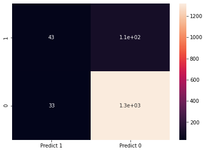

```python
cm=metrics.confusion_matrix(y_test, y_predict, labels=[1, 0])

df_cm = pd.DataFrame(cm, index = [i for i in ["1","0"]],
                  columns = [i for i in ["Predict 1","Predict 0"]])
plt.figure(figsize = (7,5))
sns.heatmap(df_cm, annot=True)
```

```python
print(df_cm)
```

```
   Predict 1  Predict 0
1         43        106
0         33       1318
```

**Above is the Confusion Matrix for Logistic Regression Model**

**Naive Bayes' Model**

```python
from sklearn.naive_bayes import GaussianNB

nb_model=GaussianNB()
nb_model.fit(x_train,y_train)
```

```
GaussianNB()
```

```python
y_predict=nb_model.predict(x_train)
train_accuracy=metrics.accuracy_score(y_train,y_predict)
train_accuracy
```

```
0.8942857142857142
```

```python
y_test_predict=nb_model.predict(x_test)
test_accuracy=metrics.accuracy_score(y_test,y_test_predict)
test_accuracy
```

```
0.884
```

```python
print(nb_model.score(x_train, y_train))
print(nb_model.score(x_test, y_test))
```

```
0.8942857142857142
0.884
```

**>> We have predicted the likelihood of a customer buying personal loan.**

**>> The training accuracy for Naive Bayes' Model is=> 89.4%**

**>> The test accuracy for Naive Bayes' Model is => 88.4%**

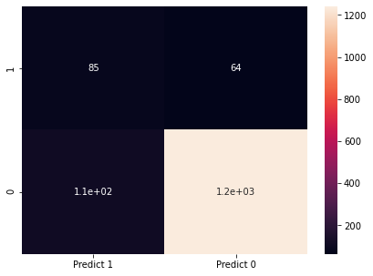

```python
nb_cm=metrics.confusion_matrix(y_test, y_test_predict, labels=[1, 0])

nb_df_cm = pd.DataFrame(nb_cm, index = [i for i in ["1","0"]],
                  columns = [i for i in ["Predict 1","Predict 0"]])
plt.figure(figsize = (7,5))
sns.heatmap(nb_df_cm, annot=True)
```

```python
print(nb_df_cm)
```

```
   Predict 1  Predict 0
1         85         64
0        110       1241
```

**Above is the Confusion Matrix for Naive Bayes' Model**

**KNN**

```python
# Finding the best value of K for good accuracy

from sklearn.neighbors import KNeighborsClassifier
scores =[]
for k in range(1,50):
    NNH_train = KNeighborsClassifier(n_neighbors = k, weights = 'distance' )
    NNH_train.fit(x_train, y_train)
    scores.append(NNH_train.score(x_test, y_test))
```

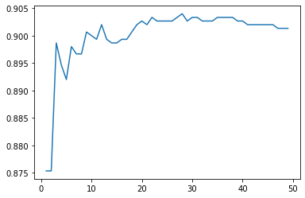

```python
plt.plot(range(1,50),scores)
```

```python
NNH = KNeighborsClassifier(n_neighbors = 29, weights = 'distance' )
NNH.fit(x_train, y_train)
```

```
KNeighborsClassifier(n_neighbors=29, weights='distance')
```

```python
KNN_predicted_labels = NNH.predict(x_test)
```

```python
print(NNH.score(x_train, y_train))
print(NNH.score(x_test, y_test))
```

```
1.0
0.9026666666666666
```

**>> We have predicted the likelihood of a customer buying personal loan.**

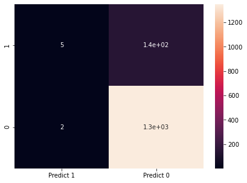

```python
from sklearn import metrics
KNN_cm=metrics.confusion_matrix(y_test, KNN_predicted_labels, labels=[1,0])

KNN_df_cm = pd.DataFrame(KNN_cm, index = [i for i in ["1","0"]],
                  columns = [i for i in ["Predict 1","Predict 0"]])
plt.figure(figsize = (7,5))
sns.heatmap(KNN_df_cm, annot=True)
```

```python
print(KNN_df_cm)
```

```
   Predict 1  Predict 0
1          5        144
0          2       1349
```

**Above is the Confusion Matrix for KNN Model**

7. Give your reasoning on which is the best model in this case and why it performs better? (5 marks)

```python
# Let us put Confusion Matrix of all the three models together for comparison of models.
# Initialising lists with models and model names.

models=[LogisticRegression(solver='liblinear'),GaussianNB(),KNeighborsClassifier(n_neighbors = 29, weights = 'distance' )]
model_names=['LR','NB','KNN']

CM=[]             # Set the confusion matrix to empty list for appending all 3 confusion matrix

Recall=[]        # Setting the parameters to empty list for appending the values for all 3 models.
Specificity=[]
Accuracy=[]
Precision=[]
Neg_Pred_value=[]
F1_Score=[]

TPs=[]
FPs=[]
TNs=[]
FNs=[]
```

```python
# Applying FOR-LOOP for calculating confusion matrix & Calculating matrix parameters.

for x,model in zip(model_names, models):

    model.fit(x_train,y_train)

    y_predict  = model.predict(x_test)


    confusion_matrix=metrics.confusion_matrix(y_test, y_predict, labels=[1, 0])
    cm = pd.DataFrame(confusion_matrix, index = [i for i in ["1","0"]],
                  columns = [i for i in [x+"_Predict 1",x+"_Predict 0"]])
    CM.append(cm)

    TP = cm.iloc[0,0]
    FP= cm.iloc[1,0]
    TN = cm.iloc[1,1]
    FN= cm.iloc[0,1]

    TPs.append(TP)
    FPs.append(FP)
    TNs.append(TN)
    FNs.append(FN)

    Recall.append(TP/(TP+FN))
    Specificity.append(TN/(TN+FP))
    Accuracy.append((TP+TN)/(TP+TN+FP+FN))
    Precision.append(TP/(TP+FP))
    Neg_Pred_value.append(TN/(TN+FN))
```

```python
# Calculation F1 Score using list of Precison & Recall.
for i,j in zip(Precision, Recall):
    f1_score=2*((i*j)/(i+j))
    F1_Score.append(f1_score)

CM_Main=pd.concat(CM,axis=1)  # Printing the CM of all three models.
CM_Main
```

|  | LR_Predict 1 | LR_Predict 0 | NB_Predict 1 | NB_Predict 0 | KNN_Predict 1 | KNN_Predict 0 |
| --- | --- | --- | --- | --- | --- | --- |
| 1 | 43 | 106 | 85 | 64 | 5 | 144 |
| 0 | 33 | 1318 | 110 | 1241 | 2 | 1349 |

```python
# Zipping lists of all the parameters to form the DataFrame for better comparions of all 3 models.
data_tuples = list(zip(TPs,FNs,TNs,FPs,Recall,Specificity,Accuracy,Precision,Neg_Pred_value,F1_Score))
df1=pd.DataFrame(data_tuples,index=['Logistic Regression','Naive Bayes','KNN'],
               columns=['TPs','FNs','TNs','FPs','Recall','Specificity','Accuracy','Precision','Neg_Pred_value','F1_Score'])
df1
```

|  | TPs | FNs | TNs | FPs | Recall | Specificity | Accuracy | Precision | Neg_Pred_value | F1_Score |
| --- | --- | --- | --- | --- | --- | --- | --- | --- | --- | --- |
| Logistic Regression | 43 | 106 | 1318 | 33 | 0.288591 | 0.975574 | 0.907333 | 0.565789 | 0.925562 | 0.382222 |
| Naive Bayes | 85 | 64 | 1241 | 110 | 0.570470 | 0.918579 | 0.884000 | 0.435897 | 0.950958 | 0.494186 |
| KNN | 5 | 144 | 1349 | 2 | 0.033557 | 0.998520 | 0.902667 | 0.714286 | 0.903550 | 0.064103 |

##### To interpret the models we need to first understand what is our requirement and accordingly what do we need from model.

##### We need to find the likelihood of a customer accepting the loan offer.

##### But likelihood of a customer accepting the loan offer depends on the customer's assessment of his ability to pay the EMI of the loan.

##### Hence, Customer's EMI paying capacity will determine his likelihood of accepting the loan offer.

##### It is fine as far as model predicts true values. We need to check to how much extent the model is predicting false values.

**>>There two types of false values: False Positives & False Negatives**

>>TPs -Acceptance of offer is predicted & customer accepts the offer -- means the customer has assessed that he has good emi paying capacity.

>>FPs - Acceptance of offer is predicted & customer does not accept the offer - means the customer has assessed that he does not have good EMI paying capacity.

>>FNs -No Acceptance of offer is predicted & customer has the capacity to pay the emi and wants emi. - Opportunity Loss

>>TNs - No Acceptance of offer is predicted & Customer also does not have the ability to pay the EMI and hence does not want the offer.

>> This means we need to minimise the False Positive values as Falsely giving the offer to a customer who does not have the EMI paying capacity may result in NPAs for bank.

1. **False Negatives** are lost opportunities. The cost of lost opportunities is a small amount of interest charged on loan.
2. **False Postitives** are predicting the customer will accept the offer and in reality cutomer has not accepted the offer. This happens when customer has assessed that he cannot pay the EMI and hence **FALSE POSITIVES** are heavy cost of extending offer to wrong people and Banks need to avoid the heavy cost to reduce the NPAs. **This is because if a customer defaults entire loan amount is to be written off from the bank's profits.**
3. Hence there is a **trade-off** between **forgone opportunies of small amount of interest charged on loan and heavy cost of NPAs.**

Conclusion:- It is important to select a model which minimizes both on False Positives & False Negatives. But practically it may not be possible to minimize both together. We have to pick either FPs or FNs to minimize more.

Here, we will pick a model which minimizes False Positives. FP means:- Acceptance of offer is predicted by model and the customer does not accept the offer.

Note that ideally model should not predict likelihood of acceptance of offer by the customer when customer does not accept the offer. This non acceptance of offer by customer may be due to his assessment of his ability to not be able to pay the EMI

### Hence False Positive(FP) is the error we need to reduce

```python
df1
```

|  | TPs | FNs | TNs | FPs | Recall | Specificity | Accuracy | Precision | Neg_Pred_value | F1_Score |
| --- | --- | --- | --- | --- | --- | --- | --- | --- | --- | --- |
| Logistic Regression | 43 | 106 | 1318 | 33 | 0.288591 | 0.975574 | 0.907333 | 0.565789 | 0.925562 | 0.382222 |
| Naive Bayes | 85 | 64 | 1241 | 110 | 0.570470 | 0.918579 | 0.884000 | 0.435897 | 0.950958 | 0.494186 |
| KNN | 5 | 144 | 1349 | 2 | 0.033557 | 0.998520 | 0.902667 | 0.714286 | 0.903550 | 0.064103 |

1. Note that total number of Positives(149) and Negatives(1351) are same for all three models.

2. LR Model is able to classify 97.5% of the Negative values correctly.

NB Model is able to classify 91.8% of the Negative values correctly.

KNN Model is able to classify 99.8% of the Negative values correctly.

3. LR Model is able to classify 28.8% of the Positive values correctly.

NB Model is able to classify 57.0% of the Positive values correctly.

KNN Model is able to classify 3.35% of the Positive values correctly.

Final Conclusion :-

KNN has the highest accuracy of classifying Negative Values correctly. KNN has the lowest FPs values as compared to other two models. On the other side, KNN also has the highest value for False Negative Values. But as discussed above, we can afford to be wrong on False Negative side. We cannot afford to be wrong on False Postive side. Also, the test accuracy of KNN is comparable with other two models.

So, out of all the three models we select KNN as the best model.